# Homework 5

### Part b) Modifying/assessing the model

Choose one of the statistically significant predictors above and re-fit a model using *only* that variable (and an intercept) to predict `am`. We’ll see how to compare the quality of this model to the one from Part (a) when we talk about cross-validation (CV) in upcoming lectures. For now, compare the estimated coefficient of this variable in both models. Is there a sizable difference?

Yes there is a sizable difference.

Does anything else notable change about the model?

```r
fitted_model2 = glm(am ~ drat, data=mtcars, family = binomial())
summary(fitted_model2)
```

```
##
## Call:
## glm(formula = am ~ drat, family = binomial(), data = mtcars)
##
## Deviance Residuals:
##     Min       1Q   Median       3Q      Max
## -1.5495  -0.2609  -0.1505   0.5382   1.7453
##
## Coefficients:
##             Estimate Std. Error z value Pr(>|z|)
## (Intercept)  -21.021      7.838  -2.682  0.00732 **
## drat           5.577      2.063   2.704  0.00685 **
## ---
## Signif. codes:  0 '***' 0.001 '**' 0.01 '*' 0.05 '.' 0.1 ' ' 1
##
## (Dispersion parameter for binomial family taken to be 1)
##
##     Null deviance: 43.23  on 31  degrees of freedom
## Residual deviance: 21.65  on 30  degrees of freedom
## AIC: 25.65
##
## Number of Fisher Scoring iterations: 6
```

Choose one of the statistically significant predictors above. Use `ggplot2` to plot `am` as a function of this predictor, and overlay a curve describing the logistic regression output when using *only* this predictor to predict `am` (i.e., the model from Part c above).

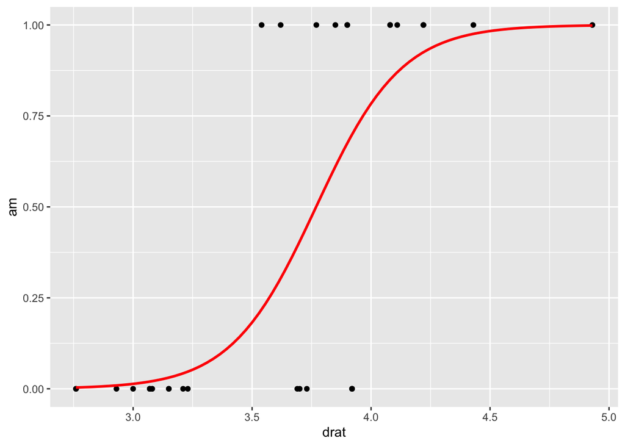

```r
library(ggplot2)

ggplot(mtcars, aes(x = drat, y = am)) +
  geom_point() +
  geom_smooth(method = "glm", method.args = list(family = "binomial"), formula = y ~ x, se = FALSE, color = "red")
```

## 3. Guided k-fold CV exercise 15pts

In this exercise, we will guide you through an exercise where you are asked to use k-fold cross validation to evaluate the performance of several models.

For this exercise we will use the “Swiss Fertility and Socioeconomic Indicators (1888)” dataset from the `datasets` package, which is loaded below. (To view the help page, run `?datasets::swiss` in your console). We will be using `Fertility` as our response variable.

```r
swiss = datasets::swiss
```

### Part a) Understanding/visualizing data

Read the help page and briefly “introduce” this dataset. Specifically, explain where the data comes from, what variables it contains, and why should people care about the dataset.

Produce one or some visualizations of the data. Do your best here to try to use your plots to help your viewer best understand the structure and patterns of this dataset. Choose your plots carefully and briefly explain what each plot tells you about the data.

The variables in the dataset are:

- Fertility (response variable)
- Agriculture
- Examination
- Education
- Catholic
- Infant.Mortality

People might be interested in this dataset because it provides insights into the relationship between socioeconomic factors and fertility rates, which can have important implications for public policy and family planning initiatives.

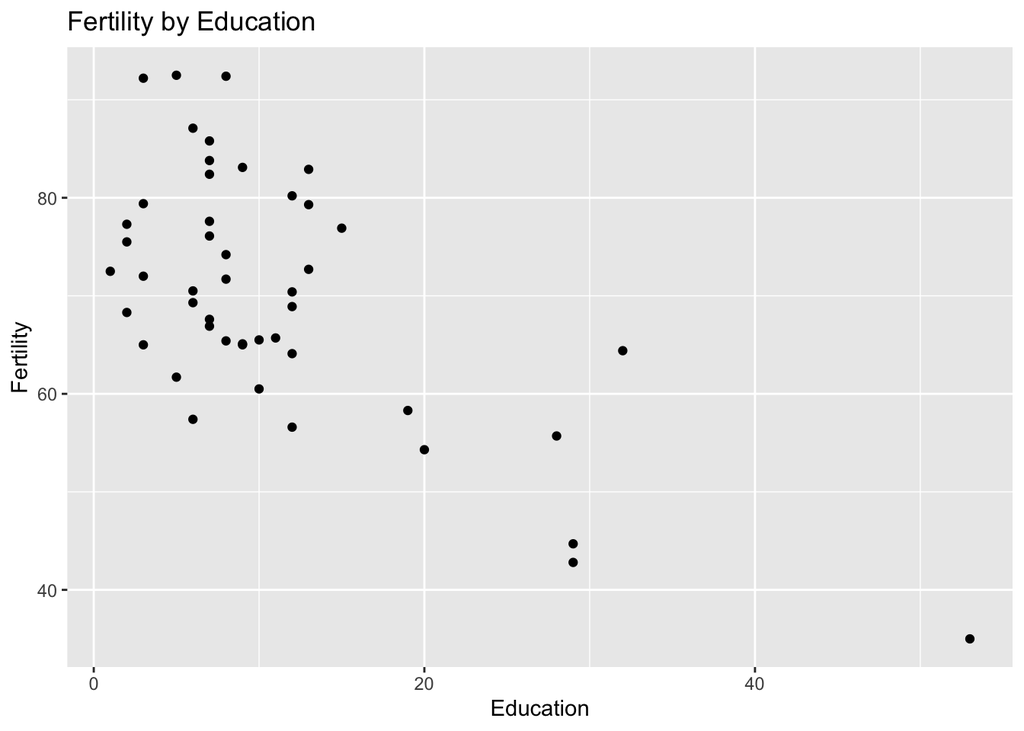

```r
ggplot(swiss, aes(x = Education, y = Fertility)) +
  geom_point() +
  labs(title = "Fertility by Education", x = "Education", y = "Fertility")
```

I chose to compare education against fertility. According to the scatterplot, it shows that people with higher eduction level (indicated by greater value) tend to have fewer fertility.

### Part b) Starting with basic lm

Compare a model with all predictors with no interactions with 2 other models of YOUR choice. Fit all 3 models, show their summary outputs, and briefly comment on which one you think might perform the best when used for future predictions and why.

```r
# Model with all predictors and no interactions
mod_all <- lm(Fertility ~ ., data = swiss)

# Model 1
mod1 <- lm(Fertility ~ Agriculture + Examination + Education + Catholic, data = swiss)

# Model 2
mod2 <- lm(Fertility ~ Agriculture + Examination + Catholic + Agriculture:Catholic + Examination:Catholic, data = swiss)

# Show summary outputs
summary(mod_all)
```

```
##
## Call:
## lm(formula = Fertility ~ ., data = swiss)
##
## Residuals:
##      Min       1Q   Median       3Q      Max
## -15.2743  -5.2617   0.5032   4.1198  15.3213
##
## Coefficients:
##                  Estimate Std. Error t value Pr(>|t|)
## (Intercept)      66.91518   10.70604   6.250 1.91e-07 ***
## Agriculture      -0.17211    0.07030  -2.448  0.01873 *
## Examination      -0.25801    0.25388  -1.016  0.31546
## Education        -0.87094    0.18303  -4.758 2.43e-05 ***
## Catholic          0.10412    0.03526   2.953  0.00519 **
## Infant.Mortality  1.07705    0.38172   2.822  0.00734 **
## ---
## Signif. codes:  0 '***' 0.001 '**' 0.01 '*' 0.05 '.' 0.1 ' ' 1
##
## Residual standard error: 7.165 on 41 degrees of freedom
## Multiple R-squared:  0.7067, Adjusted R-squared:  0.671
## F-statistic: 19.76 on 5 and 41 DF,  p-value: 5.594e-10
```

```r
summary(mod1)
```

```
##
## Call:
## lm(formula = Fertility ~ Agriculture + Examination + Education +
##     Catholic, data = swiss)
##
## Residuals:
##      Min       1Q   Median       3Q      Max
## -15.7813  -6.3308   0.8113   5.7205  15.5569
##
## Coefficients:
##             Estimate Std. Error t value Pr(>|t|)
## (Intercept) 91.05542    6.94881  13.104  < 2e-16 ***
## Agriculture -0.22065    0.07360  -2.998  0.00455 **
## Examination -0.26058    0.27411  -0.951  0.34722
## Education   -0.96161    0.19455  -4.943 1.28e-05 ***
## Catholic     0.12442    0.03727   3.339  0.00177 **
## ---
## Signif. codes:  0 '***' 0.001 '**' 0.01 '*' 0.05 '.' 0.1 ' ' 1
##
## Residual standard error: 7.736 on 42 degrees of freedom
## Multiple R-squared:  0.6498, Adjusted R-squared:  0.6164
## F-statistic: 19.48 on 4 and 42 DF,  p-value: 3.95e-09
```

```r
summary(mod2)
```

```
##
## Call:
## lm(formula = Fertility ~ Agriculture + Examination + Catholic +
##     Agriculture:Catholic + Examination:Catholic, data = swiss)
##
## Residuals:
##     Min      1Q  Median      3Q     Max
## -25.843  -5.581   1.701   5.599  19.220
##
## Coefficients:
##                       Estimate Std. Error t value Pr(>|t|)
## (Intercept)          92.799365  12.351293   7.513 3.14e-09 ***
## Agriculture          -0.143225   0.125755  -1.139    0.261
## Examination          -1.036970   0.403723  -2.569    0.014 *
## Catholic             -0.008923   0.205132  -0.043    0.966
## Agriculture:Catholic  0.001148   0.002204   0.521    0.605
## Examination:Catholic -0.001535   0.007586  -0.202    0.841
## ---
## Signif. codes:  0 '***' 0.001 '**' 0.01 '*' 0.05 '.' 0.1 ' ' 1
##
## Residual standard error: 9.782 on 41 degrees of freedom
## Multiple R-squared:  0.4534, Adjusted R-squared:  0.3867
## F-statistic: 6.802 on 5 and 41 DF,  p-value: 0.000106
```

I believe the model with all predictors perform the best when used for future prediction because it has a higher adjusted R-squared value, indicating that it explains a greater proportion of the variance in the response variable. It also has smallest F-statics p-val out of all the models so there is a strong evidence that at least one of the predictors in the model is significantly related to the response variable, and the overall model is a good fit for the data.

### Part c) Estimating MSE using CV

Now, we are going to actually estimate the MSE of each model with K-fold cross validation. First we’re going to set a seed and import the `caret` package (it should be already installed since it’s a prerequisite for many other packages, but if it’s not for some reason, you can install it with `install.packages("caret")`)

```r
set.seed(1)
library(caret)
```

Next, use the following chunk, which already has `method` set to `lm`, `data` set to the `swiss` data set, and validation method set to use 5-fold CV, to estimate the MSE of each of your models. All you need to do is add in a formula for your model and repeat for all 3 models you have.

```r
# Model 1
model1 = train(Fertility ~ .,
               method = "lm", data = swiss,
               trControl = trainControl(method = "cv", number = 5))
print(model1)
```

```
## Linear Regression
##
## 47 samples
##  5 predictor
##
## No pre-processing
## Resampling: Cross-Validated (5 fold)
## Summary of sample sizes: 37, 39, 38, 37, 37
## Resampling results:
##
##   RMSE      Rsquared   MAE
##   7.736328  0.6910525  6.242055
##
## Tuning parameter 'intercept' was held constant at a value of TRUE
```

```r
cat("RMSE for Model 1:", model1$results$RMSE, "\n")
```

```
## RMSE for Model 1: 7.736328
```

```r
cat("MSE for Model 1:", (model1$results$RMSE)^2, "\n")
```

```
## MSE for Model 1: 59.85078
```

```r
# Model 2
model2 = train(Fertility ~ Agriculture + Examination + Education + Catholic,
               method = "lm", data = swiss,
               trControl = trainControl(method = "cv", number = 5))
print(model2)
```

```
## Linear Regression
##
## 47 samples
##  4 predictor
##
## No pre-processing
## Resampling: Cross-Validated (5 fold)
## Summary of sample sizes: 37, 39, 37, 37, 38
## Resampling results:
##
##   RMSE      Rsquared   MAE
##   7.846208  0.6801395  6.625973
##
## Tuning parameter 'intercept' was held constant at a value of TRUE
```

```r
cat("RMSE for Model 2:", model2$results$RMSE, "\n")
```

```
## RMSE for Model 2: 7.846208
```

```r
cat("MSE for Model 2:", (model2$results$RMSE)^2, "\n")
```

```
## MSE for Model 2: 61.56298
```

```r
# Model 3

model3 = train(Fertility ~ Agriculture + Examination + Catholic + Agriculture:Catholic + Examination:Catholic,
               method = "lm", data = swiss,
               trControl = trainControl(method = "cv", number = 5))
print(model3)
```

```
## Linear Regression
##
## 47 samples
##  3 predictor
##
## No pre-processing
## Resampling: Cross-Validated (5 fold)
## Summary of sample sizes: 37, 38, 38, 36, 39
## Resampling results:
##
##   RMSE      Rsquared   MAE
##   10.18008  0.3818925  8.319513
##
## Tuning parameter 'intercept' was held constant at a value of TRUE
```

```r
cat("RMSE for Model 3:", model3$results$RMSE, "\n")
```

```
## RMSE for Model 3: 10.18008
```

```r
cat("MSE for Model 3:", (model3$results$RMSE)^2, "\n")
```

```
## MSE for Model 3: 103.6341
```

Once you have your models fitted, use `print( )` to show the summary statistics for each model. Report the RMSE for each model, which is the square root of the MSE. Which of these models performs the best? Which performed the worst? Do these results agree with your expectations?

Model 1 perform the best so it does agree with my expectation. Model 3 perform the worst out of 3 models.

Bonus: repeat the above step, using `trControl = trainControl(method="repeatedcv", number=5, repeats=3)` which repeats each CV analysis 3times and averages out each run to get a more stable estimate of the MSE. Compare the results with the unrepeated MSE estimates. How do they compare?

```r
# Model 1
model1 = train(Fertility ~ .,
               method = "lm", data = swiss,
               trControl = trainControl(method = "repeatedcv", number = 5, repeats = 3))
print(model1)
```

```
## Linear Regression
##
## 47 samples
##  5 predictor
##
## No pre-processing
## Resampling: Cross-Validated (5 fold, repeated 3 times)
## Summary of sample sizes: 38, 38, 38, 37, 37, 39, ...
## Resampling results:
##
##   RMSE      Rsquared   MAE
##   7.611755  0.6690312  6.18519
##
## Tuning parameter 'intercept' was held constant at a value of TRUE
```

```r
cat("RMSE for Model 1:", model1$results$RMSE, "\n")
```

```
## RMSE for Model 1: 7.611755
```

```r
cat("MSE for Model 1:", (model1$results$RMSE)^2, "\n")
```

```
## MSE for Model 1: 57.93882
```

```r
# Model 2
model2 = train(Fertility ~ Agriculture + Examination + Education + Catholic,
               method = "lm", data = swiss,
               trControl = trainControl(method = "repeatedcv", number = 5,  repeats = 3))
print(model2)
```

```
## Linear Regression
##
## 47 samples
##  4 predictor
##
## No pre-processing
## Resampling: Cross-Validated (5 fold, repeated 3 times)
## Summary of sample sizes: 37, 39, 38, 37, 37, 38, ...
## Resampling results:
##
##   RMSE      Rsquared   MAE
##   8.105416  0.6582624  6.878331
##
## Tuning parameter 'intercept' was held constant at a value of TRUE
```

```r
cat("RMSE for Model 2:", model2$results$RMSE, "\n")
```

```
## RMSE for Model 2: 8.105416
```

```r
cat("MSE for Model 2:", (model2$results$RMSE)^2, "\n")
```

```
## MSE for Model 2: 65.69777
```

```r
# Model 3

model3 = train(Fertility ~ Agriculture + Examination + Catholic + Agriculture:Catholic + Examination:Catholic,
               method = "lm", data = swiss,
               trControl = trainControl(method = "repeatedcv", number = 5, repeats = 3))
print(model3)
```

```
## Linear Regression
##
## 47 samples
##  3 predictor
##
## No pre-processing
## Resampling: Cross-Validated (5 fold, repeated 3 times)
## Summary of sample sizes: 37, 39, 37, 38, 37, 36, ...
## Resampling results:
##
##   RMSE      Rsquared  MAE
##   10.10444  0.403197  8.329688
##
## Tuning parameter 'intercept' was held constant at a value of TRUE
```

```r
cat("RMSE for Model 3:", model3$results$RMSE, "\n")
```

```
## RMSE for Model 3: 10.10444
```

```r
cat("MSE for Model 3:", (model3$results$RMSE)^2, "\n")
```

```
## MSE for Model 3: 102.0998
```

## 5. Variable selection with `Carseats` 10pts

This question should be answered using the `Carseats` dataset from the `ISLR` package. If you do not have it, make sure to install it.

```r
library(ISLR)

Carseats = ISLR::Carseats

# you should read the help page by running ?Carseats
# we can also peek at the data frame before using it
str(Carseats)
```

```
## 'data.frame':    400 obs. of  11 variables:
##  $ Sales      : num  9.5 11.22 10.06 7.4 4.15 ...
##  $ CompPrice  : num  138 111 113 117 141 124 115 136 132 132 ...
##  $ Income     : num  73 48 35 100 64 113 105 81 110 113 ...
##  $ Advertising: num  11 16 10 4 3 13 0 15 0 0 ...
##  $ Population : num  276 260 269 466 340 501 45 425 108 131 ...
##  $ Price      : num  120 83 80 97 128 72 108 120 124 124 ...
##  $ ShelveLoc  : Factor w/ 3 levels "Bad","Good","Medium": 1 2 3 3 1 1 3 2 3 3 ...
##  $ Age        : num  42 65 59 55 38 78 71 67 76 76 ...
##  $ Education  : num  17 10 12 14 13 16 15 10 10 17 ...
##  $ Urban      : Factor w/ 2 levels "No","Yes": 2 2 2 2 2 1 2 2 1 1 ...
##  $ US         : Factor w/ 2 levels "No","Yes": 2 2 2 2 1 2 1 2 1 2 ...
```

```r
head(Carseats)
```

```
##   Sales CompPrice Income Advertising Population Price ShelveLoc Age Education
## 1  9.50       138     73          11        276   120       Bad  42        17
## 2 11.22       111     48          16        260    83      Good  65        10
## 3 10.06       113     35          10        269    80    Medium  59        12
## 4  7.40       117    100           4        466    97    Medium  55        14
## 5  4.15       141     64           3        340   128       Bad  38        13
## 6 10.81       124    113          13        501    72       Bad  78        16
##   Urban  US
## 1   Yes Yes
## 2   Yes Yes
## 3   Yes Yes
## 4   Yes Yes
## 5   Yes  No
## 6    No Yes
```

### Part a) Visualizing/fitting

First, make some visualizations of the dataset to help set the stage for the rest of the analysis. Try to pick plots to show that are interesting informative.

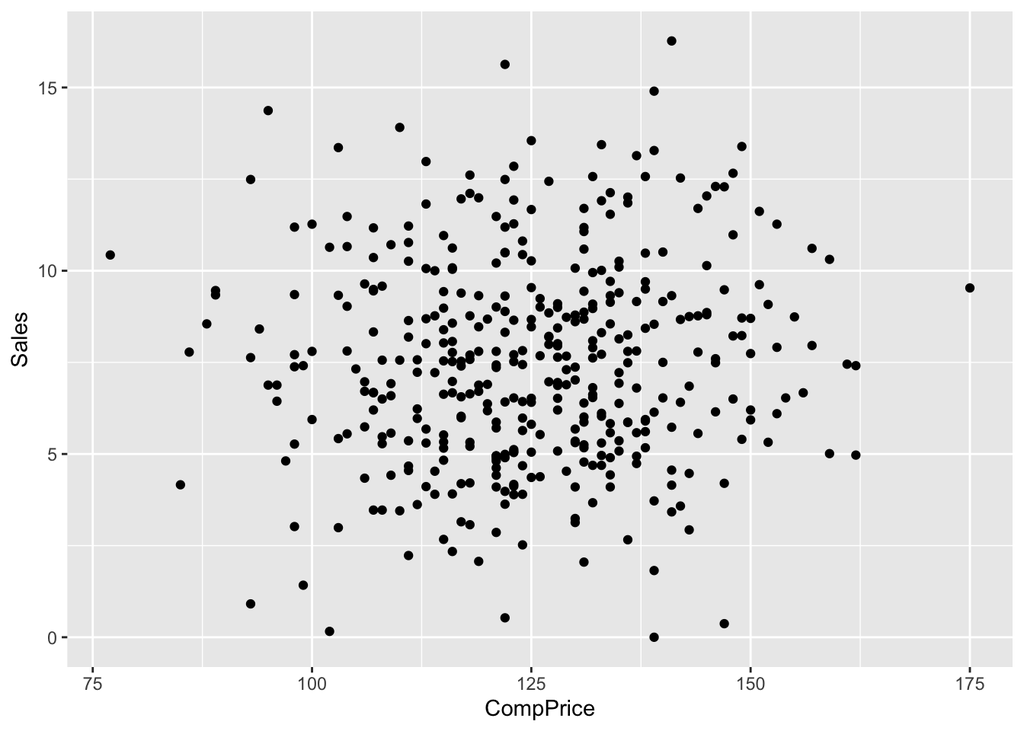

```r
# Scatter plot of Sales vs. CompPrice
ggplot(Carseats, aes(x = CompPrice, y = Sales)) +
  geom_point() +
  labs(x = "CompPrice", y = "Sales")
```

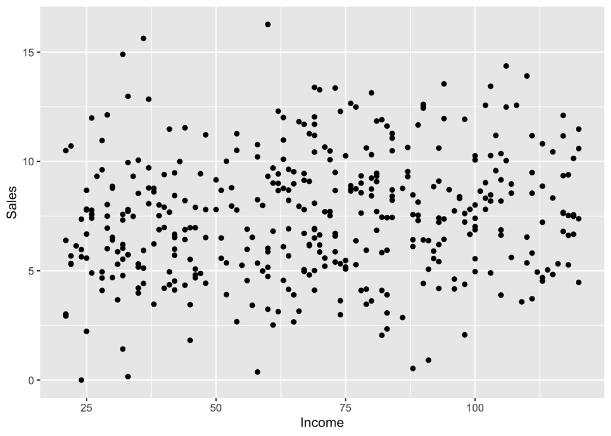

```r
# Scatter plot of Sales vs. Income
ggplot(Carseats, aes(x = Income, y = Sales)) +
  geom_point() +
  labs(x = "Income", y = "Sales")
```

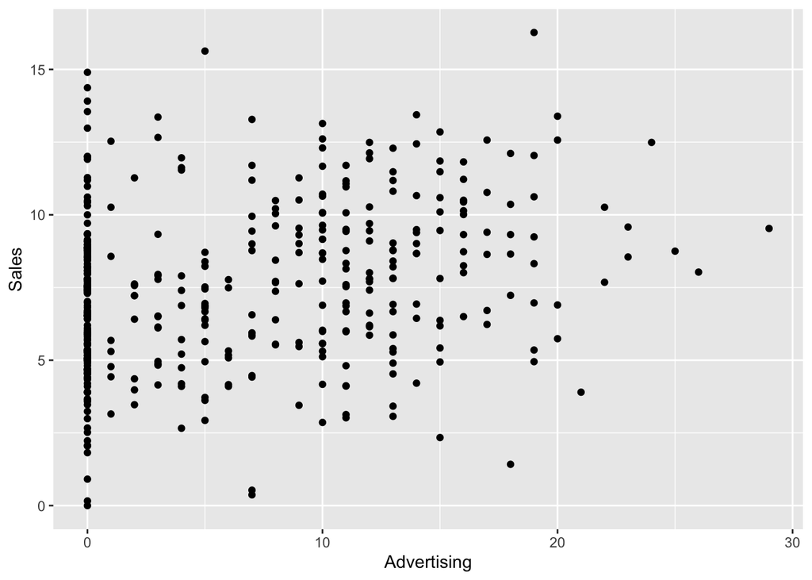

```r
# Scatter plot of Sales vs. Advertising
ggplot(Carseats, aes(x = Advertising, y = Sales)) +
  geom_point() +
  labs(x = "Advertising", y = "Sales")
```

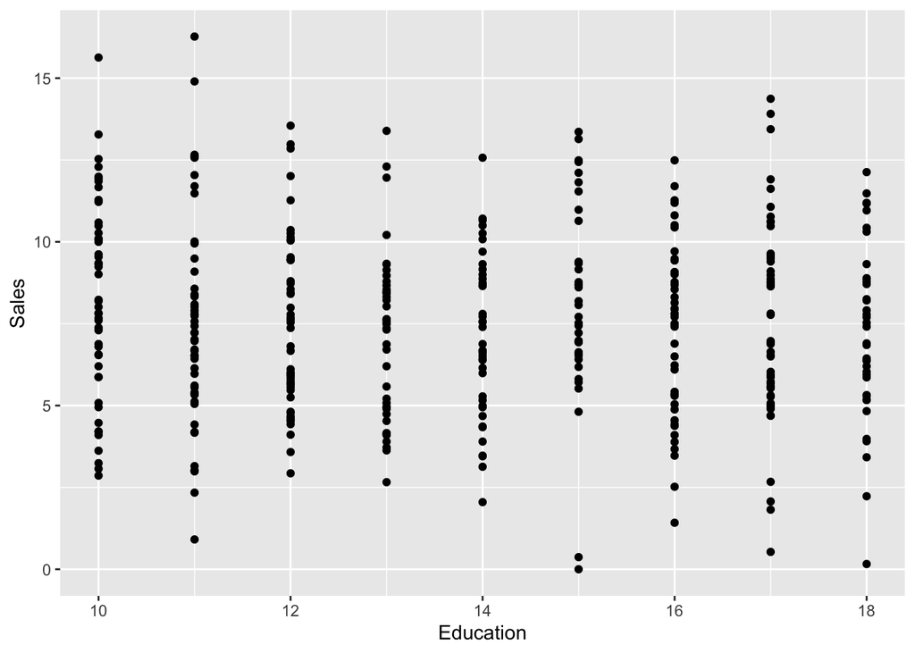

```r
ggplot(Carseats, aes(x = Education, y = Sales)) +
  geom_point() +
  labs(x = "Education", y = "Sales")
```

Using some variable selection method (stepwise, LASSO, ridge, or just manually comparing a preselected of models using their MSEs), choose a set of predictors to use to predict `Sales`. Try to find the best model that you can that explains the data well and doesn’t have useless predictors. Explain the choices you made and show the final model.

```r
library(glmnet)

x = model.matrix(Sales~.,Carseats)[,-1]
y = Carseats$Sales

# fit lasso using default lambda values, alpha=1 adds LASSO penalty to RSS
lm.lasso = glmnet(x,y,alpha=1)

# use CV to choose which lambda gives lowest MSE
cv.out = cv.glmnet(x,y,alpha=1)
lambda.best = cv.out$lambda.min
lambda.best
```

```
## [1] 0.004020658
```

```r
coef(lm.lasso, s = lambda.best)
```

```
## 12 x 1 sparse Matrix of class "dgCMatrix"
##                            s1
## (Intercept)      5.6957309820
## CompPrice        0.0921113330
## Income           0.0156249685
## Advertising      0.1212334764
## Population       0.0001911429
## Price           -0.0949007158
## ShelveLocGood    4.8246673212
## ShelveLocMedium  1.9367369589
## Age             -0.0457870708
## Education       -0.0196066560
## UrbanYes         0.1127092155
## USYes           -0.1563113249
```

```r
model_fit <- lm(Sales ~ CompPrice + Income + Advertising + Price + ShelveLoc + Age , data = Carseats)

summary(model_fit)
```

```
##
## Call:
## lm(formula = Sales ~ CompPrice + Income + Advertising + Price +
##     ShelveLoc + Age, data = Carseats)
##
## Residuals:
##     Min      1Q  Median      3Q     Max
## -2.7728 -0.6954  0.0282  0.6732  3.3292
##
## Coefficients:
##                  Estimate Std. Error t value Pr(>|t|)
## (Intercept)      5.475226   0.505005   10.84   <2e-16 ***
## CompPrice        0.092571   0.004123   22.45   <2e-16 ***
## Income           0.015785   0.001838    8.59   <2e-16 ***
## Advertising      0.115903   0.007724   15.01   <2e-16 ***
## Price           -0.095319   0.002670  -35.70   <2e-16 ***
## ShelveLocGood    4.835675   0.152499   31.71   <2e-16 ***
## ShelveLocMedium  1.951993   0.125375   15.57   <2e-16 ***
## Age             -0.046128   0.003177  -14.52   <2e-16 ***
## ---
## Signif. codes:  0 '***' 0.001 '**' 0.01 '*' 0.05 '.' 0.1 ' ' 1
##
## Residual standard error: 1.019 on 392 degrees of freedom
## Multiple R-squared:  0.872,  Adjusted R-squared:  0.8697
## F-statistic: 381.4 on 7 and 392 DF,  p-value: < 2.2e-16
```

I used Lasso regression to find the coefficients that might be significant in predicting sales. All of the coefficients are not equal to zero, which means that the corresponding predictors are important for predicting Sales. However, population’s coefficient estimate is very small almost close to 0 so we can negate that. As for Education, Urban and US coefficient, I tried fitting but its p-value is greater than 0.05 so it’s not significant in predicting Sales. Therefore, I removed those coefficients.

### Part b) Interpreting/assessing model

According to your chosen model, Which predictors appear to be the most important or significant in predicting sales? Provide an interpretation of each coefficient in your model. Be careful: some of the variables in the model are qualitative!

I would say CompPrice, Income, Advertising, Price, ShelveLoc, and Age are all significants predictors for sales. For a one-unit increase in competitor’s price, the predicted sales increased by 0.09 units sales (in thousands), holding all other variables constant.This indicates that the company’s car seats are considered more attractive than the competitor’s when the competitor’s prices are higher. Holding all other variables constant, for a one unit (in thousands of dollars) increase in the community income level, the sales increase by 0.015785 units (in thousands). This suggests that the company is most likely to sell car seats when there is increase in income level (in thousands of dollars) at community. Holding all other variables constant, for a one-unit increase in the advertising budget (in thousands of dollars), the sales increase by 0.115903 units (in thousands). This implies that advertising is an effective way to increase sales for the company. Holding all other variables constant, for a one-unit increase in the company’s child car seat price, the sales decrease by 0.095319 units (in thousands). This indicates that customers are sensitive to the price of the car seats, and the company should consider adjusting its prices to maximize sales. Holding all other variables constant, having a good quality of the shelving location for the car seats at each site results in an increase in sales of 4.835675 units (in thousands). Likewise, holding other variables constant, having a medium quality of the shelving location for the car seats at each site results in an increase in sales of 1.951993 units (in thousands). This also suggests that having a good and medium quality shelving location for the car seats is important for sales. Lastly, holding all other variables constant, for a one-unit increase in the average age of the local population, the sales decrease by 0.046128 units (in thousands). This indicates that the company’s car seats are more attractive to customers in younger age groups.

Estimate the out of sample MSE of your model and check any assumptions you made during your model fitting process. Discuss any potential model violations. How satisfied are you with your final model?

```r
train <- sample(nrow(Carseats), nrow(Carseats) * 0.7)
train_data <- Carseats[train, ]
test_data <- Carseats[-train, ]
fit <- lm(Sales ~ CompPrice + Income + Advertising + Price + ShelveLoc + Age, data = train_data)
pred <- predict(fit, newdata = test_data)
mse <- mean((pred - test_data$Sales)^2)
mse
```

```
## [1] 0.9513958
```